# STT 301: Vectors

Rellika Kisyula

September 12, 2018

## Introduction

**Learning objectives:**

- Vector subsetting
- Vector arithmetic
- Vector subsetting with logical vectors
- Basic R graphics

First, we will set code chunk options to be in force for the whole document, unless overridden by the options in an individual code chunk. Typically we would use `echo = FALSE` in this chunk, since we wouldn’t want it seen in the final document.

The world `global_options` is just the name of the chunk. You can provide a name for each chunk by placing the name after the `r`.

```r
knitr::opts_chunk$set(comment = NA, tidy = TRUE)
```

Today we will get some practice manipulating vectors in `R`. Download the file `triplecrown.Rdata` from D2L and put it in the working directory with this R Markdown file.

## Vector subsetting

The triple crown of horse racing involves three races: Kentucky Derby, Preakness, and Belmont Stakes. The data set consists of four vectors: year, derby, belmont, and preakness. The winning time (in seconds) is given with respect to each race and year and coincides with the `years` vector.

```r
load("triplecrown.Rdata")
ls()  # lists all variables in the environment
```

```
[1] "belmont"   "derby"     "preakness" "years"
```

*You may see more variables other than the four associated with this data* *set depending on what is in your working environment.*

First, let us see what years we are given.

```r
years
```

```
 [1] 1926 1927 1928 1929 1930 1931 1932 1933 1934 1935 1936 1937 1938 1939
[15] 1940 1941 1942 1943 1944 1945 1946 1947 1948 1949 1950 1951 1952 1953
[29] 1954 1955 1956 1957 1958 1959 1960 1961 1962 1963 1964 1965 1966 1967
[43] 1968 1969 1970 1971 1972 1973 1974 1975 1976 1977 1978 1979 1980 1981
[57] 1982 1983 1984 1985 1986 1987 1988 1989 1990 1991 1992 1993 1994 1995
[71] 1996 1997 1998 1999 2000 2001 2002 2003 2004 2005 2006 2007 2008 2009
[85] 2010 2011 2012 2013 2014 2015 2016 2017
```

Let’s extract the five oldest (1926-1930) winning times for each of the three races.

```r
derby[c(1:5)]
```

```
[1] 123.8 126.0 130.4 130.8 127.6
```

```r
preakness[c(1:5)]
```

```
[1] 119.8 121.6 120.2 121.6 120.6
```

```r
belmont[c(1:5)]
```

```
[1] 152.2 152.4 153.2 152.8 151.6
```

Let’s extract the five most recent (2013-2017) winning times for each of the three races.

```r
derby[(length(derby) - 4):length(derby)]
```

```
[1] 122.89 123.66 123.02 121.31 123.59
```

```r
preakness[(length(preakness) - 4):length(preakness)]
```

```
[1] 117.54 114.84 118.46 118.31 115.98
```

```r
belmont[(length(belmont) - 4):length(belmont)]
```

```
[1] 150.70 148.52 146.65 148.51 150.02
```

```r
# Why does this not work?
belmont[length(belmont) - 4:length(belmont)]
```

```
 [1] 150.70 150.42 150.88 151.57 147.54 149.65 148.74 147.81 148.75 147.50
[11] 148.26 149.71 146.80 151.20 147.80 149.00 148.80 148.80 152.00 146.80
[21] 149.80 146.00 148.00 147.40 146.00 146.40 148.20 149.80 147.00 147.20
[31] 147.80 148.20 149.00 149.80 148.60 146.80 149.60 149.00 148.20 149.20
[41] 144.00 148.00 150.40 154.00 148.80 147.20 148.80 149.60 148.40 148.40
[51] 150.20 148.80 149.20 149.60 148.40 150.20 146.60 149.80 149.00 150.80
[61] 158.60 150.20 149.00 148.60 150.20 148.20 149.40 150.80 150.20 152.20
[71] 148.20 149.20 151.00 149.60 149.60 149.40 148.60 150.00 150.60 149.20
[81] 152.60 152.80 149.60 151.60 152.80 153.20 152.40 152.20
```

Explain why the above line of code does not work? What is R doing?

What type of vectors are `years`, `derby`, `preakness`, and `belmont`?

```r
# List the types here...
```

## Vector manipulation

Compute the average winning time over the most recent 10 years for each of the three races.

```r
# Compute the means here..
```

What do you observe with regards to the mean winning times?

We will combine the three race vectors by column. To do this we utilize the `cbind` function. We will save this as a variable named `all.races`.

```r
all.races <- cbind(derby, preakness, belmont)
```

Let’s create a comparison boxplot for each of the three races.

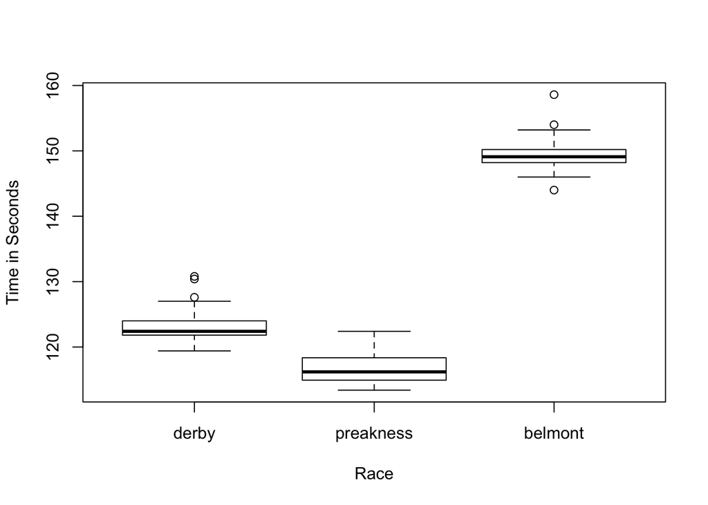

```r
boxplot(all.races, ylab = "Time in Seconds", xlab = "Race")
```

```r
# ylab, and xlab are graphical parameters that allow you to put labels on
# the y axis and x axis, respectively.
```

What do you observe in the above boxplot? Why may this be?

If a single horse wins all three races (Kentucky Derby, Preakness, and Belmont Stakes) in a given year, he/she is deemed to have won the triple crown. Since 1926 only 11 horses have won the triple crown. We will list the years in which there was a triple crown winner.

```r
tc.winner.years <- c(1930, 1935, 1937, 1941, 1943, 1946, 1948, 1973, 1977, 1978,
    2015)
tc.winner.years
```

```
 [1] 1930 1935 1937 1941 1943 1946 1948 1973 1977 1978 2015
```

```r
length(tc.winner.years)
```

```
[1] 11
```

For the three races, we will compute the average winning time for the years corresponding to a triple crown winner. First, to find the locations in the vector `years`, where a horse won the triple crown, we will use a more advanced subsetting technique that will be discussed later.

```r
location <- which(years %in% tc.winner.years)
location
```

```
 [1]  5 10 12 16 18 21 23 48 52 53 90
```

To check we did this right we can use the `location` variable to subset the `years` vector and check to see if the years match `tc.winner.years`.

```r
years[location]
```

```
 [1] 1930 1935 1937 1941 1943 1946 1948 1973 1977 1978 2015
```

Now, use the `location` vector to subset each of the race variables and then compute the mean winning time.

```r
# Compute means here...
```

Create a new vector named `tc.winner` that takes on the value `FALSE` for the year a horse did not win the triple crown and the value `TRUE` for the year a horse did win the triple crown. This vector should be the same length as the vector `years`.

```r
# Create the vector here...
```

For the 11 horses that won the triple crown we will now list their names. The names below are already listed in order in terms of the year the horse won the triple crown. Hence, Gallant Fox was the name of the horse that won the triple crown in 1930. American Pharoah was the name of the horse that won the triple crown in 2015.

```r
tc.winner.names <- c("Gallant Fox", "Omaha", "War Admiral", "Whirlaway", "Count Fleet",
    "Assault", "Citation", "Secretariat", "Seattle Slew", "Affirmed", "American Pharoah")
tc.winner.names
```

```
 [1] "Gallant Fox"      "Omaha"            "War Admiral"
 [4] "Whirlaway"        "Count Fleet"      "Assault"
 [7] "Citation"         "Secretariat"      "Seattle Slew"
[10] "Affirmed"         "American Pharoah"
```

Attach the above names to the horses’ respective times for each race.

```r
tc.winner.derby <- derby[location]
names(tc.winner.derby) <- tc.winner.names
tc.winner.derby
```

```
     Gallant Fox            Omaha      War Admiral        Whirlaway
          127.60           125.00           123.20           122.40
     Count Fleet          Assault         Citation      Secretariat
          124.00           126.60           125.40           119.40
    Seattle Slew         Affirmed American Pharoah
          122.20           121.20           123.02
```

```r
# Mimic the above for the two other races and save the variables as
# tc.winner.preakness and tc.winner.belmont
```

Sort the variables `tc.winner.derby`, `tc.winner.preakness`, and `tc.winner.belmont` from fastest to slowest. Remember, you can use the `sort` function.

```r
# Sort variables here...
```

What do you notice?

Finally, we will use a base plot functions in `R` to create a bar plot for each of the races with regards to the triple crown winners and their times. To create a bar plot you can use the `R` command `barplot`.

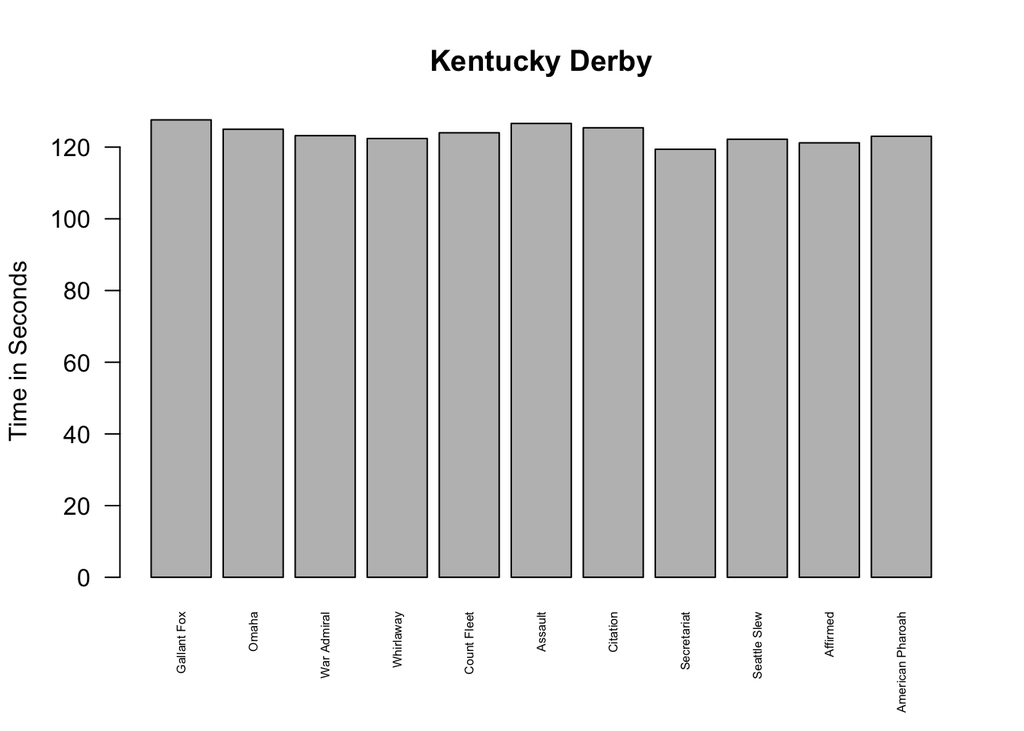

```r
barplot(tc.winner.derby, las = 2, cex.names = 0.5, ylab = "Time in Seconds",
    main = "Kentucky Derby")
```

```r
# Graphical Parameters las - changes orientation of horse names cex.names -
# scales the size of horse names <1 shirnks; >1 enlarges main - provides a
# title for the plot (all axis labels and titles should be in ' ')
```

```r
# Create bar plot here for tc.winner.preakness
```

```r
# Create bar plot here for tc.winner.belmont
```

Some information about each race is given below.

| Race | Race Length |
| --- | --- |
| Kentucky Derby | 2000 meters |
| Preakness | 1900 meters |
| Belmont Stakes | 2400 meters |

## More advanced vector subsetting

So far we have directly specified the elements a of vector that we want to extract. Typically, we want to extract elements that meet a condition, such as all the years where the winning Kentucky Derby time was faster than 123.00 seconds. For this we perform subsetting with logical vectors. This is formally discussed in Section 4.7 of the notes, but we will informally use it now.

Let’s look at some examples with very simple vectors, and then you’ll use these ideas for the triple crown data vectors.

```r
set.seed(123)  # Set the seed for reproducible random number generation

x <- rbinom(10, 20, 0.9)  # Generate 10 binomial(n=20, p=0.9) values
y <- rbinom(10, 20, 0.8)  # Generate 10 binomial(n=20, p=0.8) values
x
```

```
 [1] 19 17 18 16 16 20 18 16 18 18
```

```r
y
```

```
 [1] 13 16 15 16 18 14 17 19 17 13
```

```r
x[x > 16]  # Values of x which are larger than 16
```

```
[1] 19 17 18 20 18 18 18
```

```r
x[x == 18]  # Values of x which are equal to 18
```

```
[1] 18 18 18 18
```

```r
length(x[x == 18])  # How many values of x are equal to 18?
```

```
[1] 4
```

```r
x[y < 15]  # Values of x for which the corresponding values of y are less than 15
```

```
[1] 19 20 18
```

```r
x[x < y]  # Values of x which are less than the correponding values of y
```

```
[1] 16 16
```

```r
x[x == 18] <- 0  # Replace 18 by 0 in x
x
```

```
 [1] 19 17  0 16 16 20  0 16  0  0
```

Use the above concepts to answer the questions below.

1. How many Kentucky Derby winners had a time faster than 121.00?
2. How many Belmont Stakes winners ran a faster time than the overall mean winning time?
3. In what years was the winning Kentucky Derby time faster than the winning Preakness time?
4. How many Belmont Stakes winners had a winning time between 148.00 and 152.00 seconds (inclusive)? In what years did this occur?

```r
# Answers to a-d here...
```

## Data analysis review

Data on the number, in thousands, of international airline passengers from 1949-1960 are built in to `R`. These are in the form of a time series, and we’ll first convert these to a vector since that’s the type of data structure we currently know how to manipulate.

```r
passengers <- as.vector(AirPassengers)
passengers
```

```
  [1] 112 118 132 129 121 135 148 148 136 119 104 118 115 126 141 135 125
 [18] 149 170 170 158 133 114 140 145 150 178 163 172 178 199 199 184 162
 [35] 146 166 171 180 193 181 183 218 230 242 209 191 172 194 196 196 236
 [52] 235 229 243 264 272 237 211 180 201 204 188 235 227 234 264 302 293
 [69] 259 229 203 229 242 233 267 269 270 315 364 347 312 274 237 278 284
 [86] 277 317 313 318 374 413 405 355 306 271 306 315 301 356 348 355 422
[103] 465 467 404 347 305 336 340 318 362 348 363 435 491 505 404 359 310
[120] 337 360 342 406 396 420 472 548 559 463 407 362 405 417 391 419 461
[137] 472 535 622 606 508 461 390 432
```

Investigate these data using `R` functions such as `mean`, `max`, `min`, `summary`, `sd`, `length`, etc.

```r
# Show your preliminary explorations here
```

Draw a histogram of the number of passengers using the `hist` function. You can add a title and label if you want using the graphical parameters mentioned above.

```r
# Draw the histogram here
```

What do you notice?

Create a scatter plot of the number of passengers using the `plot` function. The main arguments to `plot` are `x` and `y`, vectors of x and y values. First draw the scatter plot with no further arguments, and then add the graphical parameter argument `type = "l"` which asks `R` to connect the points. Again, you may add a title and labels using the graphical parameters mentioned above.

```r
# Draw plot here
```

What do you notice from the scatter plot?